# Tidy Tuesday - Eurovision

Rich Posert

2022-05-17

I know next to nothing about Eurovision, so this will be a learning exercise in more ways than one. I know it’s a song competition, that each country submits one contestant, and that Australia is in it. I also think that there’s a meme about the UK being bad at it.

## First Impressions

Let’s load up the data and see what we’re dealing with:

```r
library(tidyverse)
# full_tt_dataset <- tidytuesdayR::tt_load('2022-05-17')
# eurovision <- full_tt_dataset$eurovision
# votes <- full_tt_dataset$`eurovision-votes`
eurovision <- read_csv('eurovision.csv')
votes <- read_csv('votes.csv')


glimpse(eurovision)
```

```
## Rows: 2,005
## Columns: 18
## $ event          <chr> "Turin 2022", "Turin 2022", "Turin 2022", "Turin 2022",…
## $ host_city      <chr> "Turin", "Turin", "Turin", "Turin", "Turin", "Turin", "…
## $ year           <dbl> 2022, 2022, 2022, 2022, 2022, 2022, 2022, 2022, 2022, 2…
## $ host_country   <chr> "Italy", "Italy", "Italy", "Italy", "Italy", "Italy", "…
## $ event_url      <chr> "https://eurovision.tv/event/turin-2022", "https://euro…
## $ section        <chr> "first-semi-final", "first-semi-final", "first-semi-fin…
## $ artist         <chr> "Kalush Orchestra", "S10", "Amanda Georgiadi Tenfjord",…
## $ song           <chr> "Stefania", "De Diepte", "Die Together", "Saudade, Saud…
## $ artist_url     <chr> "https://eurovision.tv/participant/kalush-orchestra-22"…
## $ image_url      <chr> "https://static.eurovision.tv/hb-cgi/images/963164d0-06…
## $ artist_country <chr> "Ukraine", "Netherlands", "Greece", "Portugal", "Bulgar…
## $ country_emoji  <chr> ":flag_ua:", ":flag_nl:", ":flag_gr:", ":flag_pt:", ":f…
## $ running_order  <dbl> 6, 8, 15, 10, 7, 5, 17, 16, 3, 9, 4, 14, 11, 1, 12, 2, …
## $ total_points   <dbl> 337, 221, 211, 208, 29, 15, 187, 177, 159, 154, 118, 10…
## $ rank           <dbl> 1, 2, 3, 4, 16, 17, 5, 6, 7, 8, 9, 10, 11, 12, 13, 14, …
## $ rank_ordinal   <chr> "1st", "2nd", "3rd", "4th", "16th", "17th", "5th", "6th…
## $ qualified      <lgl> TRUE, TRUE, TRUE, TRUE, FALSE, FALSE, TRUE, TRUE, TRUE,…
## $ winner         <lgl> FALSE, FALSE, FALSE, FALSE, FALSE, FALSE, FALSE, FALSE,…
```

```r
glimpse(votes)
```

```
## Rows: 56,312
## Columns: 8
## $ year               <dbl> 1975, 1975, 1975, 1975, 1975, 1975, 1975, 1975, 197…
## $ semi_final         <chr> "f", "f", "f", "f", "f", "f", "f", "f", "f", "f", "…
## $ edition            <chr> "1975f", "1975f", "1975f", "1975f", "1975f", "1975f…
## $ jury_or_televoting <chr> "J", "J", "J", "J", "J", "J", "J", "J", "J", "J", "…
## $ from_country       <chr> "Belgium", "Belgium", "Belgium", "Belgium", "Belgiu…
## $ to_country         <chr> "Belgium", "Finland", "France", "Germany", "Ireland…
## $ points             <dbl> 0, 0, 2, 0, 12, 1, 6, 0, 7, 0, 0, 0, 4, 0, 8, 3, 0,…
## $ duplicate          <chr> "x", NA, NA, NA, NA, NA, NA, NA, NA, NA, NA, NA, NA…
```

Wow! The first ideas that jump out to me are: 1. How often does the host country win? Is there a home field advantage?

This question would be difficult to answer though, since I have no idea how often a country is expected to win in the first place. Presumably if you (as a country) love Eurovision, you’re more likely to both find good acts and to want to host it, so I doubt the two events can be treated as independent.

2. Which artists have competed the most times? And when?
3. Are the trajectories of countries’ placements (i.e., winner, second place, etc.) interesting?
4. Are voters more likely to vote for their own country if they’re the host?

Ignoring question 1 since I don’t think I’d be able to answer it, let’s explore the data:

## Prolific Artists

```r
eurovision |>
  count(artist) |>
  count(n)
```

```
## # A tibble: 4 × 2
##       n    nn
##   <int> <int>
## 1     1  1159
## 2     2   355
## 3     3    32
## 4     4    10
```

Alright, nobody has performed more than 4 times, and ten people have performed 4 times. Not particularly interesting.

## Country Placements

I wonder if we can see any rags-to-riches or fall-from-grace stories in how well the countries do each year:

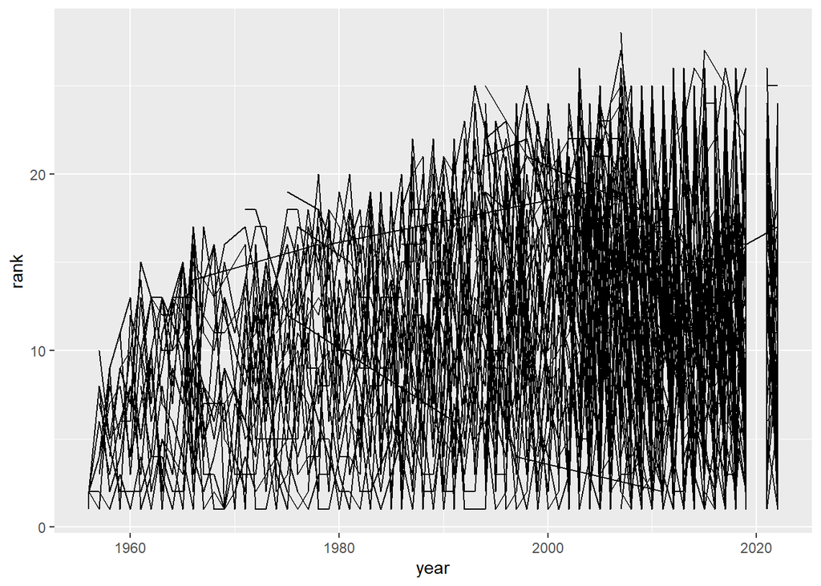

```r
eurovision |>
  ggplot(aes(x = year, y = rank, group = artist_country)) +
  geom_line()
```

Hm…that’s hard to read…